# YouTube Viewing Behaviour

## Introduction

This visual data story explores YouTube viewing behaviour based on a dataset of logged watch activity. The aim is to identify patterns in video length, device usage, and viewing time. The analysis uses R to clean, summarise, and visualise the data.

## Distribution of YouTube Video Lengths

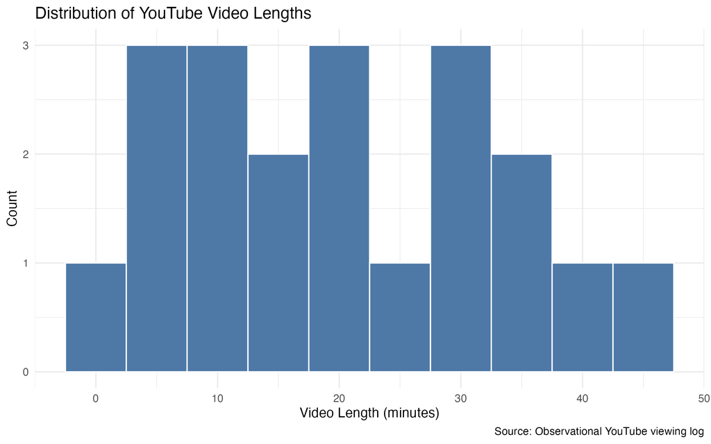

Histogram showing distribution of YouTube video lengths

## Device Usage and Viewing Behaviour

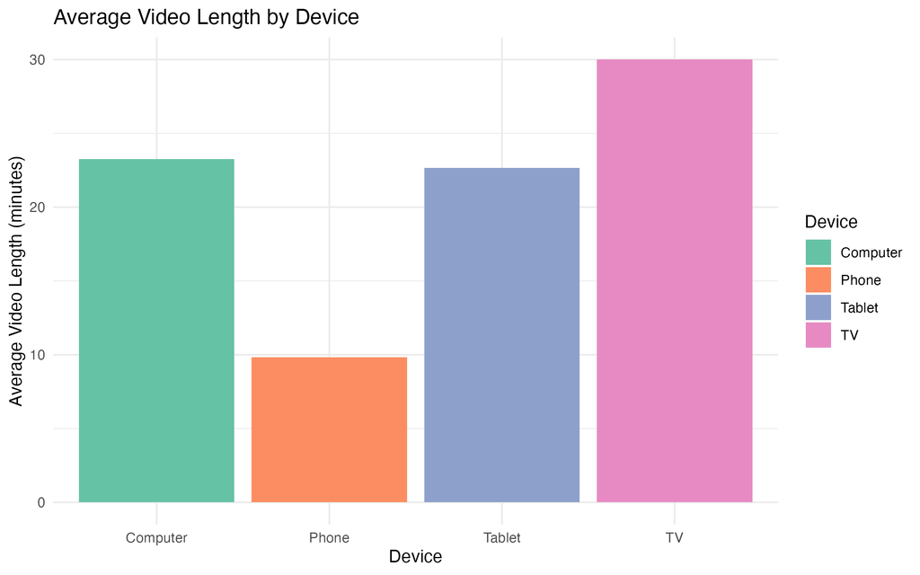

Bar chart showing average video length by device

This chart compares average video length across different devices. It helps show whether viewing behaviour changes depending on the device used.